# MJMSTable

## Introduction

The `MJMSTable` package is designed to streamline the process of creating publication-ready statistical tables that adhere to the formatting requirements of the *Malaysian Journal of Medical Sciences* (MJMS). Built on top of `gtsummary` and `gt`, this package provides wrapper functions for common statistical tests, automatically applying the correct themes, layouts, and footnotes.

### Setup

First, load the package. For this vignette, we will use a hypothetical dataset called `mjms_data` that comes with the package.

```r
library(MJMSTable)

# View the structure of the dataset
head(mjms_data)
```

```
#>   PatientID Age  BMI Cholesterol    Sex Smoker Treatment_Group SBP_Left_Arm
#> 1         1  46 25.2       225.5 Female    Yes          Drug_A          155
#> 2         2  44 30.8       193.5   Male     No          Drug_A          156
#> 3         3  58 34.0       248.8 Female     No         Placebo          149
#> 4         4  62 24.7       190.8   Male    Yes         Placebo          135
#> 5         5  71 25.7       206.4   Male     No          Drug_A          161
#> 6         6  74 21.3       240.1   Male     No          Drug_A          153
#>   SBP_Right_Arm Heart_Disease Diagnosis_Doc_A Diagnosis_Doc_B Gold_Standard
#> 1           162            No        Positive        Negative       Healthy
#> 2           159            No        Positive        Positive       Disease
#> 3           153           Yes        Negative        Negative       Healthy
#> 4           135            No        Positive        Positive       Disease
#> 5           165            No        Positive        Negative       Disease
#> 6           157           Yes        Negative        Negative       Healthy
#>   New_Test_Result Symptom_Pre Symptom_Post
#> 1        Negative         Yes          Yes
#> 2        Positive          No           No
#> 3        Negative          No           No
#> 4        Positive         Yes          Yes
#> 5        Negative          No          Yes
#> 6        Negative          No           No
```

## 1. Descriptive Statistics

The `descriptive_tbl()` function provides a clean summary of demographic or baseline characteristics, grouped by a specific variable.

```r
descriptive_tbl(
  data = mjms_data,
  group_var = "Treatment_Group",
  included_var = c("Age", "BMI", "Sex", "Smoker"),
  non_normal_vars = c("Age"),
  table_caption = "Baseline Patient Characteristics",
  abbreviation = "BMI = Body Mass Index, SBP = Systolic Blood Pressure"
)
```

**Table :** Baseline Patient Characteristics (*n* = 500)

| **Variables** | **Drug_A** ( *n* = 196) | **Drug_B** ( *n* = 152) | **Placebo** ( *n* = 152) | **Total** *n* (%) |
| --- | --- | --- | --- | --- |
| Age<sup>a</sup> | 54.0 (16.0) | 55.0 (19.0) | 56.0 (17.5) | 55.0 (18.0) |
| BMI<sup>b</sup> | 26.0 (4.6) | 27.2 (4.7) | 27.0 (5.1) | 26.7 (4.8) |
| Sex |  |  |  |  |
| Female | 101 (51.5) | 70 (46.1) | 72 (47.4) | 243 (48.6) |
| Male | 95 (48.5) | 82 (53.9) | 80 (52.6) | 257 (51.4) |
| Smoker | 71 (36.2) | 55 (36.2) | 30 (19.7) | 156 (31.2) |

<sup>a</sup> Median (IQR)  
<sup>b</sup> Mean (SD)  
Abbreviation: BMI = Body Mass Index, SBP = Systolic Blood Pressure

## 2. Comparing Means

### Independent t-test

Compare continuous variables between two independent groups using `ttest_tbl()`. You can toggle between standard and Welch’s t-test using the `equal_var` argument.

```r
ttest_tbl(
  data = mjms_data,
  outcome_var = "BMI",
  group_var = "Sex",
  equal_var = TRUE,
  table_caption = "Comparison of BMI by Biological Sex",
  abbreviation = "BMI = body mass index"
)
```

**Table :** Comparison of BMI by Biological Sex

| **Variable** | **Mean (SD)** **Male** *n* = 257 | **Mean (SD)** **Female** *n* = 243 | Mean difference (95% CI) | *t*-statistic (df) | *P***-value**<sup>a</sup> |  |  |  |
| --- | --- | --- | --- | --- | --- | --- | --- | --- |
| BMI | 26.50 (4.86) | 26.87 (4.73) |  |  |  | 0.37 (-0.47, 1.21) | 0.862 (498) | 0.389 |

<sup>a</sup> Independent *t*-test.  
Abbreviation: BMI = body mass index

### Paired t-test

For paired continuous data (e.g., pre- and post-measurements or paired body parts), use `paired_ttest_tbl()`.

```r
paired_ttest_tbl(
  data = mjms_data,
  id_var = "PatientID",
  pre_var = "SBP_Left_Arm",
  post_var = "SBP_Right_Arm",
  variable_label = "Systolic Blood Pressure (mmHg)",
  table_caption = "Comparison of SBP between Left and Right Arms"
)
```

**Table :** Comparison of SBP between Left and Right Arms

| **Variable** | **Mean (SD)** *n* = 500 **SBP_Right_Arm** | **Mean (SD)** *n* = 500 **SBP_Left_Arm** | Mean difference (95% CI) | *t*-statistic (df) | *P***-value**<sup>a</sup> |  |  |  |
| --- | --- | --- | --- | --- | --- | --- | --- | --- |
| Systolic Blood Pressure (mmHg) | 142.01 (12.04) | 145.87 (12.16) |  |  |  | 3.9 (3.7, 4.0) | -44.946 (499) | <0.001 |

<sup>a</sup> Paired *t*-test.

### One-Way ANOVA

When comparing means across more than two groups, `anova_tbl()` provides the F-statistic, degrees of freedom, and post-hoc adjustment results.

```r
anova_tbl(
  data = mjms_data,
  outcome_var = "Cholesterol",
  group_var = "Treatment_Group",
  outcome_label = "Serum Cholesterol"
)
```

**Table :** Comparison of means between groups

[output not shown]

<sup>a</sup> One-way ANOVA.  
<sup>b</sup> Sig. differences (p < 0.05): Drug_B vs Drug_A

## 3. Categorical Associations

### Chi-square Test

Evaluate the association between two categorical variables with `chisq_tbl()`.

```r
chisq_tbl(
  data = mjms_data,
  exposure_var = "Sex",
  outcome_var = "Smoker",
  table_caption = "Association of Gender vs. Smoking Status"
)
```

**Table :** Association of Gender vs. Smoking Status

| **Variable** | **Smoker** **No** *n* (%) | **Smoker** **Yes** *n* (%) | *n* | χ² **-statistic** (df) | *P***-value**<sup>a</sup> |  |  |  |
| --- | --- | --- | --- | --- | --- | --- | --- | --- |
| Sex |  |  |  |  |  |  | 0.11 (1) | 0.745 |
| Female | 165 (48.0) | 78 (50.0) | 243 |  |  |  |  |  |
| Male | 179 (52.0) | 78 (50.0) | 257 |  |  |  |  |  |

<sup>a</sup> Chi-square test for independence.

### McNemar Test

For paired categorical data, `mcnemar_tbl()` computes McNemar’s Chi-squared test with continuity correction.

```r
mcnemar_tbl(
  data = mjms_data,
  pre_var = "Symptom_Pre",
  post_var = "Symptom_Post",
  table_caption = "Symptom status pre- and post-treatment",
  header_pre = "Pre Symptom",
  header_post = "Post Symptom"
)
```

**Table :** Symptom status pre- and post-treatment

| **Pre Symptom** | **Post Symptom** **No** *n* (%) | **Post Symptom** **Yes** *n* (%) | *n* | χ² **-statistic** (df) | *P***-value**<sup>a</sup> |  |  |  |
| --- | --- | --- | --- | --- | --- | --- | --- | --- |
| Pre Symptom |  |  |  |  |  |  | 136.94 (1) | <0.001 |
| No | 168 (33.6) | 39 (7.8) | 207 |  |  |  |  |  |
| Yes | 233 (46.6) | 60 (12.0) | 293 |  |  |  |  |  |

<sup>a</sup> McNemar’s Chi-squared test with continuity correction.

## 4. Regression Analyses

### Linear Regression

Summarize Simple or Multiple Linear Regression models using `lm_tbl()`. Interaction terms can be included using standard R formula syntax, “*” or “:”.

```r
lm_tbl(
  data = mjms_data,
  outcome_var = "Cholesterol",
  predictor_vars = c("Age * BMI", "Smoker"), # "Age * BMI" adds an interaction term
  var_labels = list(Age ~ "Age (Years)", BMI ~ "Body Mass Index"),
  table_caption = "Multiple Linear Regression for Cholesterol"
)
```

**Table :** Multiple Linear Regression for Cholesterol (*n* = 500).

| **Factors** | **Adjusted** *b***(95% CI)**<sup>a</sup> | *t*-statistic | *P***-value**<sup>b</sup> |
| --- | --- | --- | --- |
| Age (Years) | -0.20 (-1.3, 0.93) | -0.350 | 0.727 |
| Body Mass Index | -0.26 (-2.7, 2.1) | -0.215 | 0.830 |
| Smoker |  | - |  |
| No | — | - |  |
| Yes | 0.79 (-4.8, 6.4) | 0.278 | 0.781 |
| Age (Years) * Body Mass Index | 0.01 (-0.03, 0.05) | 0.551 | 0.582 |

<sup>a</sup> Adjusted regression coefficients,  
<sup>b</sup> Multiple linear regression (R² =0.007).

### Logistic Regression

For binary outcomes, `logistic_tbl()` outputs Adjusted Odds Ratios, 95% CIs, and Wald statistics. You can also explicitly define reference levels. Interaction terms can be included using standard R formula syntax, “*” or “:”.

```r
logistic_tbl(
  data = mjms_data,
  outcome_var = "Heart_Disease",
  predictor_vars = c("Age * Sex", "Smoker"), # "Age * Sex" adds an interaction term
  ref_levels = list(Smoker = "No", Sex = "Female"),
  cat_vars = c("Sex", "Smoker"),
  table_caption = "Risk Factors for Heart Disease"
)
```

**Table :** Risk Factors for Heart Disease (*n* = 500).

| **Factors** | *b* | Adjusted OR (95% CI) | **Wald statistic** | *P***-value**<sup>a</sup> |
| --- | --- | --- | --- | --- |
| Age | -0.00 | 1.00 (0.97, 1.03) | -0.019 | 0.985 |
| Sex | - |  | - |  |
| Female | - | — | - |  |
| Male | -0.53 | 0.59 (0.06, 5.29) | -0.469 | 0.639 |
| Smoker | - |  | - |  |
| No | - | — | - |  |
| Yes | -0.07 | 0.93 (0.54, 1.55) | -0.275 | 0.783 |
| Age * Sex | - |  | - |  |
| Age * Male | 0.00 | 1.00 (0.97, 1.04) | 0.198 | 0.843 |

<sup>a</sup> Likelihood ratio test.

## 5. Advanced Analyses

### Diagnostic Test (Sensitivity, Specificity, AUC)

Analyze the performance of medical markers against a gold standard using `diagnostic_tbl()`. It handles multiple markers at once and optionally generates an ROC plot.

```r
# Define index markers and their cutoffs
med_marker <- list(
  Cholesterol  = list(label = "Serum Cholesterol (Cutoff: 200)", cutoff = 200),
  BMI          = list(label = "Body Mass Index (Cutoff: 25)", cutoff = 25),
  SBP_Left_Arm = list(label = "Systolic BP - Left (Cutoff: 140)", cutoff = 140)
)

diag_results <- diagnostic_tbl(
  data = mjms_data,
  status_var = "Gold_Standard",
  marker_map = med_marker,
  show_plot = TRUE,
  plot_marker = "Cholesterol",
  table_caption = "Diagnostic Accuracy of Cardiovascular Markers",
  abbreviation = "AUC = Area Under Curve; SBP = Systolic Blood Pressure"
)

# View outputs
diag_results$table
```

Diagnostic Accuracy of Cardiovascular Markers (n = 500)

| **Variable (cutoff)** | Sensitivity (%) (95% CI) | Specificity (%) (95% CI) | **AUC (95% CI)** | *P***-value**<sup>a</sup> |
| --- | --- | --- | --- | --- |
| Serum Cholesterol (Cutoff: 200) | 67.1 (61.1, 72.6) | 41.1 (35.1, 46.8) | 0.53 (0.48, 0.58) | 0.29 |
| Body Mass Index (Cutoff: 25) | 67.5 (61.5, 73) | 37.9 (31.9, 44) | 0.51 (0.46, 0.57) | 0.56 |
| Systolic BP - Left (Cutoff: 140) | 44 (38.1, 50) | 54.8 (48.8, 60.9) | 0.5 (0.45, 0.55) | 0.95 |

<sup>a</sup> Null hypothesis: true area = 0.5.  
Abbreviation: AUC = Area Under Curve; SBP = Systolic Blood Pressure

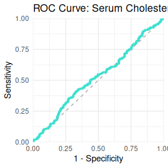

```r
diag_results$plot
```

### Pearson Correlation

Generate a clean correlation matrix with embedded p-values and standard deviations using `pearson_tbl()`.

```r
pearson_tbl(
  data = mjms_data,
  included_var = c("Age", "BMI", "SBP_Left_Arm", "SBP_Right_Arm"),
  abbreviation = "BMI = body mass index; SBP = systolic blood pressure",
  table_caption = "Correlation between clinical variables"
)
```

**Correlation between clinical variables** (n = 500)

| Variables | Age | BMI | SBP_Left_Arm | SBP_Right_Arm |
| --- | --- | --- | --- | --- |
| Age | 12.427<sup>a</sup> | 0.850<sup>b</sup> | 0.847<sup>b</sup> | 0.949<sup>b</sup> |
| BMI | 0.008<sup>c</sup> | 4.799<sup>a</sup> | 0.260<sup>b</sup> | 0.292<sup>b</sup> |
| SBP_Left_Arm | -0.009<sup>c</sup> | -0.051<sup>c</sup> | 12.040<sup>a</sup> | < 0.001<sup>b</sup> |
| SBP_Right_Arm | -0.003<sup>c</sup> | -0.047<sup>c</sup> | 0.987<sup>c</sup> | 12.159<sup>a</sup> |

<sup>a</sup> Standard Deviation (SD)  
<sup>b</sup> P-value  
<sup>c</sup> Pearson correlation coefficient (r)  
Abbreviation: BMI = body mass index; SBP = systolic blood pressure